# Econ HW 2

Maddie Berger & Sara Orofino

4/25/2019

### 1. Aggregate Demand, Supply, and Surplus

**High income demand curve:**  
$Price = 23.3914418 - (1.2966378\times 10^{-4})Q$

**Low income demand curve:**  
$Price = 21.9908534 - (1.3551741\times 10^{-4})Q$

#### a. Find aggregate demand

**Aggregate demand curve:**  
$Price = 22.7066059 - (6.6262994\times 10^{-5})Q$

#### b. Find the supply curve

**Supply curve:**  
$Price = (1.8711376\times 10^{-5})*Q$

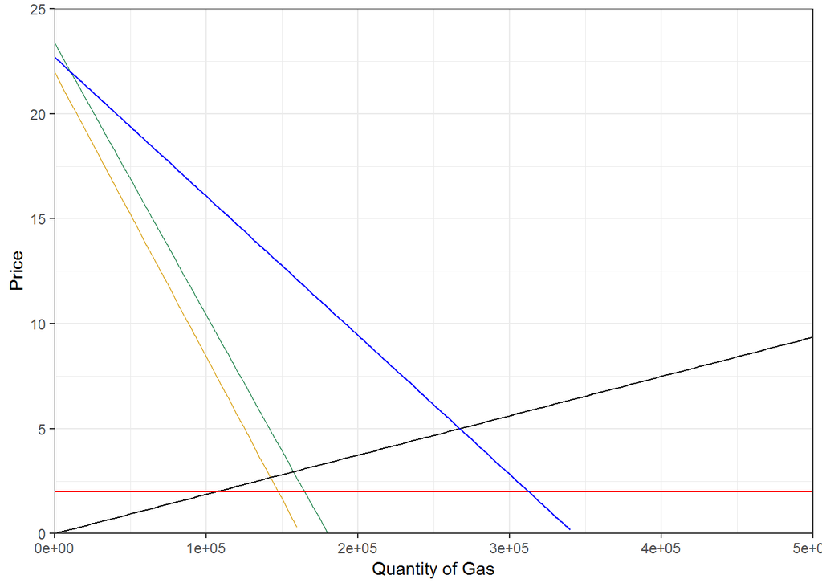

#### c. Surplus under the status quo

**Consumers:**  
$CS = 2.3694528~Million~USD$

**Producers:**  
$PS = 0.6680428~Million~USD$

#### d. Environmental Cost under the Status Quo

$Environmental~Cost = 0.5344342~Million~USD$

### 2. Division of Consumer Benefit

**Consumer Surplus for High Income**  
$CS_{High} = 1.3043162~Million~USD$

**Consumer Surplus for Low Income**  
$CS_{Low} = 1.0651366~Million~USD$

### 3. Implement a Gas Tax of $0.50/gallon

#### a. New quantity of gasoline

$Q_{Tax} = 2.6133299\times 10^{5}$

#### b. New price of gasoline

$P_{Tax} = 5.3898999$

#### c. Surplus to high income consumers

$CS_{High} = 1.2495992~Million~USD$

#### d. Surplus to low income consumers

$CS_{Low} = 1.0168127~Million~USD$

#### e. Producer surplus

$PS_{Tax} = 0.6389461~Million~USD$

#### f. Environmental damage

$TEC_{Tax} = 0.522666~Million~USD$

#### g. Tax revenue

$Tax~Revenue = 0.1306665~Million~USD$

### 4. Tax Revenues for Infrastructure Repairs

#### a. Surplus to high income consumers

Table 1. High Income Consumer Welfare at Variable Gas Tax Amounts

| Tax Amount | High Income Consumer Welfare (Million USD) |
| --- | --- |
| 0.25 | 1.3119 |
| 0.50 | 1.3190 |
| 0.75 | 1.3257 |
| 1.00 | 1.3319 |
| 1.25 | 1.3376 |
| 1.50 | 1.3429 |
| 1.75 | 1.3477 |
| 2.00 | 1.3521 |
| 2.25 | 1.3560 |
| 2.50 | 1.3595 |
| 2.75 | 1.3625 |
| 3.00 | 1.3650 |
| 3.25 | 1.3671 |
| 3.50 | 1.3687 |
| 3.75 | 1.3698 |
| 4.00 | 1.3705 |
| 4.25 | 1.3708 |
| 4.50 | 1.3706 |
| 4.75 | 1.3699 |
| 5.00 | 1.3688 |

#### b. Surplus to low income consumers

Table 2. Low Income Consumer Welfare at Variable Gas Tax Amounts

| Tax Amount | Low Income Consumer Welfare (Million USD) |
| --- | --- |
| 0.25 | 0.5433 |
| 0.50 | 0.5554 |
| 0.75 | 0.5671 |
| 1.00 | 0.5783 |
| 1.25 | 0.5891 |
| 1.50 | 0.5995 |
| 1.75 | 0.6095 |
| 2.00 | 0.6189 |
| 2.25 | 0.6280 |
| 2.50 | 0.6366 |
| 2.75 | 0.6448 |
| 3.00 | 0.6525 |
| 3.25 | 0.6598 |
| 3.50 | 0.6667 |
| 3.75 | 0.6731 |
| 4.00 | 0.6791 |
| 4.25 | 0.6847 |
| 4.50 | 0.6898 |
| 4.75 | 0.6944 |
| 5.00 | 0.6987 |

#### c. Surplus to producers

Table 3. Producer Welfare at Variable Gas Tax Amounts

| Tax Amount | Producer Welfare (Million USD) |
| --- | --- |
| 0.25 | 0.6534 |
| 0.50 | 0.6389 |
| 0.75 | 0.6246 |
| 1.00 | 0.6105 |
| 1.25 | 0.5965 |
| 1.50 | 0.5827 |
| 1.75 | 0.5690 |
| 2.00 | 0.5555 |
| 2.25 | 0.5422 |
| 2.50 | 0.5290 |
| 2.75 | 0.5160 |
| 3.00 | 0.5032 |
| 3.25 | 0.4905 |
| 3.50 | 0.4780 |
| 3.75 | 0.4656 |
| 4.00 | 0.4534 |
| 4.25 | 0.4414 |
| 4.50 | 0.4295 |
| 4.75 | 0.4178 |
| 5.00 | 0.4062 |

#### Possible Revenues and Welfare Changes from Gas Tax:

**Assumptions**  
- Benefits from infrastructure repairs are proportional to amount driven  
- Low income consumers pay the entire environmental cost

Figure 4. Comparison of Revenue and Welfare Potential with Variable Gas Tax Amounts

| Tax Amount (USD) | Tax Revenue (Million USD) | Welfare Change Low Income (%) | Welfare Change High Income (%) | Welfare Change Producers (%) |
| --- | --- | --- | --- | --- |
| 0.25 | 0.0661 | -48.9954 | 0.5811 | -2.1899 |
| 0.50 | 0.1307 | -47.8567 | 1.1270 | -4.3555 |
| 0.75 | 0.1938 | -46.7593 | 1.6377 | -6.4969 |
| 1.00 | 0.2554 | -45.7031 | 2.1133 | -8.6141 |
| 1.25 | 0.3156 | -44.6881 | 2.5537 | -10.7070 |
| 1.50 | 0.3743 | -43.7142 | 2.9589 | -12.7756 |
| 1.75 | 0.4316 | -42.7816 | 3.3290 | -14.8200 |
| 2.00 | 0.4874 | -41.8902 | 3.6640 | -16.8402 |
| 2.25 | 0.5417 | -41.0399 | 3.9637 | -18.8361 |
| 2.50 | 0.5945 | -40.2309 | 4.2283 | -20.8078 |
| 2.75 | 0.6458 | -39.4631 | 4.4577 | -22.7553 |
| 3.00 | 0.6957 | -38.7365 | 4.6520 | -24.6785 |
| 3.25 | 0.7442 | -38.0510 | 4.8111 | -26.5774 |
| 3.50 | 0.7911 | -37.4068 | 4.9351 | -28.4521 |
| 3.75 | 0.8366 | -36.8038 | 5.0238 | -30.3026 |
| 4.00 | 0.8806 | -36.2419 | 5.0774 | -32.1288 |
| 4.25 | 0.9231 | -35.7213 | 5.0959 | -33.9308 |
| 4.50 | 0.9642 | -35.2419 | 5.0792 | -35.7085 |
| 4.75 | 1.0038 | -34.8036 | 5.0273 | -37.4620 |
| 5.00 | 1.0419 | -34.4066 | 4.9403 | -39.1912 |

### 5. Electric cars lower demand for each group by one half (vertically)

#### a. & b. Gas consumption by High/Low income Consumers

Low Income Consumption:  
$Q_{Low} = 7.129296\times 10^{4}$

High Income Consumption:  
$Q_{High} = 7.8825332\times 10^{4}$

#### c. New price of gasoline with higher EV use and lower gas demand

$Price = 0.906898$

#### d. Environmental Cost

$Environmental~Cost = 0.3153013 ~Million~USD$

### 6. Compare a 2.00 per gal tax to the influence of EV

Table 5. Environmental Cost Comparison

|  | Environmental Cost (USD) | Reduction (%) |
| --- | --- | --- |
| Baseline | 0.5344 | 0.0000 |
| $2.00 Gas Tax | 0.4874 | 8.8080 |
| High EV Demand | 0.3153 | 41.0028 |